# Lista 6 - Iago Dutra

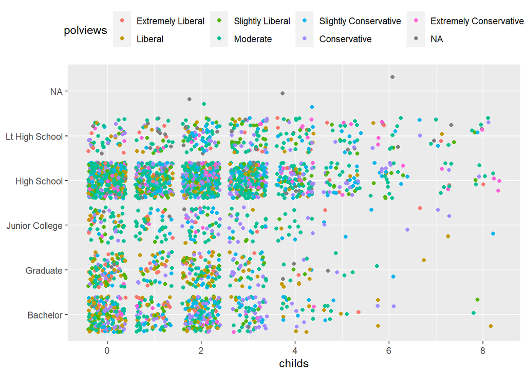

```r
p <- ggplot(gss_sm, mapping = aes(x = reorder(degree, childs, na.rm=TRUE), y = childs, color = polviews))
p + geom_jitter() + labs(x=NULL) + coord_flip() + theme(legend.position = "top")
```

A aplicação do jitter permitiu visualizar os dados anteriormente sobrepostos. Como a variável childs é categórica, não há prejuízo para a exatidão da informação.

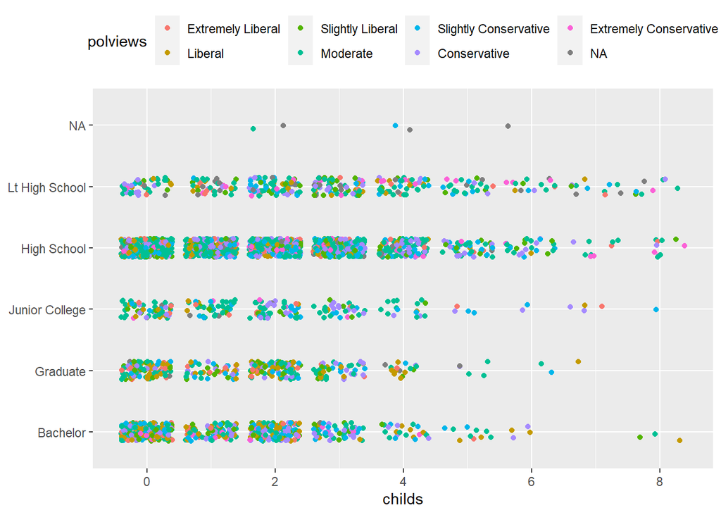

```r
p <- ggplot(gss_sm, mapping = aes(x = reorder(degree, childs, na.rm=TRUE), y = childs, color = polviews))

p + geom_jitter(position = position_jitter(width=0.15)) +
    labs(x=NULL) + coord_flip() +
    theme(legend.position = "top")
```

```r
by_degree <- gss_sm %>%
              group_by(degree, sex) %>%
              summarize(childs_mean= mean(childs, na.rm = TRUE),
                        childs_sd = sd(childs, na.rm = TRUE),
                        sibs_mean = mean(sibs, na.rm = TRUE))
by_degree
```

| degree | sex | childs_mean | childs_sd | sibs_mean |
| --- | --- | --- | --- | --- |
| Lt High School | Male | 2.600000 | 2.042602 | 5.517007 |
| Lt High School | Female | 2.972376 | 1.924783 | 6.011050 |
| High School | Male | 1.704992 | 1.712465 | 3.729198 |
| High School | Female | 1.996241 | 1.582919 | 3.880952 |
| Junior College | Male | 1.651685 | 1.771627 | 3.662921 |
| Junior College | Female | 1.849206 | 1.518249 | 3.904762 |
| Bachelor | Male | 1.407407 | 1.527525 | 2.646091 |
| Bachelor | Female | 1.491468 | 1.356401 | 3.102389 |
| Graduate | Male | 1.636364 | 1.431770 | 2.295455 |
| Graduate | Female | 1.435484 | 1.347121 | 2.494624 |

[output cut: 2 more lines]

```r
by_country <- by_degree

by_degree <- gss_sm %>%
              group_by(degree, sibs) %>%
              summarize_if(is.numeric, funs(mean, sd), na.rm = TRUE) %>%
              ungroup()
by_degree
```

| degree | sibs | year_mean | id_mean | ballot_mean | age_mean | childs_mean | pres12_mean | wtssall_mean | obama_mean | year_sd | id_sd | ballot_sd | age_sd | childs_sd | pres12_sd | wtssall_sd | obama_sd |
| --- | --- | --- | --- | --- | --- | --- | --- | --- | --- | --- | --- | --- | --- | --- | --- | --- | --- |
| Lt High School | 0 | 2016 | 1274.2727 | 2.090909 | 47.63636 | 2.3636364 | 1.200000 | 0.8817098 | 0.8000000 | 0 | 1006.592777 | 0.8312094 | 23.640105 | 2.5796406 | 0.4472136 | 0.4369517 | 0.4472136 |
| Lt High School | 1 | 2016 | 1507.2917 | 2.125000 | 40.75000 | 2.2916667 | 1.285714 | 0.9930400 | 0.7142857 | 0 | 823.494435 | 0.8501918 | 18.639019 | 2.2742255 | 0.4879500 | 0.5155247 | 0.4879500 |
| Lt High School | 2 | 2016 | 1626.4762 | 1.761905 | 49.04762 | 2.0476190 | 1.000000 | 1.3916808 | 1.0000000 | 0 | 804.005635 | 0.7684245 | 21.599713 | 1.6271506 | 0.0000000 | 0.7698436 | 0.0000000 |
| Lt High School | 3 | 2016 | 1571.0000 | 2.000000 | 48.91429 | 2.5142857 | 1.500000 | 1.0151054 | 0.5000000 | 0 | 754.804610 | 0.8401681 | 18.762245 | 1.9609636 | 0.5345225 | 0.5935561 | 0.5345225 |
| Lt High School | 4 | 2016 | 1420.8600 | 2.020000 | 50.02000 | 2.5714286 | 1.250000 | 0.9603109 | 0.7500000 | 0 | 820.450001 | 0.7951383 | 19.235904 | 1.6832508 | 0.4472136 | 0.4065072 | 0.4472136 |
| Lt High School | 5 | 2016 | 1889.8750 | 2.000000 | 59.69231 | 3.2000000 | 1.352941 | 1.0632832 | 0.6470588 | 0 | 840.031293 | 0.8770580 | 18.623915 | 2.0531402 | 0.4925922 | 0.6413244 | 0.4925922 |
| Lt High School | 6 | 2016 | 1429.1944 | 1.916667 | 56.77778 | 2.4857143 | 1.133333 | 1.0436542 | 0.8666667 | 0 | 829.664263 | 0.9063270 | 15.908867 | 1.5972666 | 0.3518658 | 0.5734196 | 0.3518658 |
| Lt High School | 7 | 2016 | 1364.0000 | 2.227273 | 48.31818 | 2.9090909 | 1.000000 | 1.1920656 | 1.0000000 | 0 | 916.057027 | 0.7516216 | 20.162167 | 2.4477218 | 0.0000000 | 0.7804617 | 0.0000000 |
| Lt High School | 8 | 2016 | 1446.0435 | 1.739130 | 52.08696 | 2.9565217 | 1.000000 | 0.9662025 | 1.0000000 | 0 | 929.425457 | 0.7518094 | 13.760659 | 1.9418422 | 0.0000000 | 0.4075344 | 0.0000000 |
| Lt High School | 9 | 2016 | 1670.4211 | 2.000000 | 56.78947 | 3.8421053 | 1.333333 | 0.8950070 | 0.6666667 | 0 | 782.840009 | 0.8164966 | 17.443811 | 2.1670040 | 0.5163978 | 0.2888491 | 0.5163978 |

[output cut: 83 more lines]

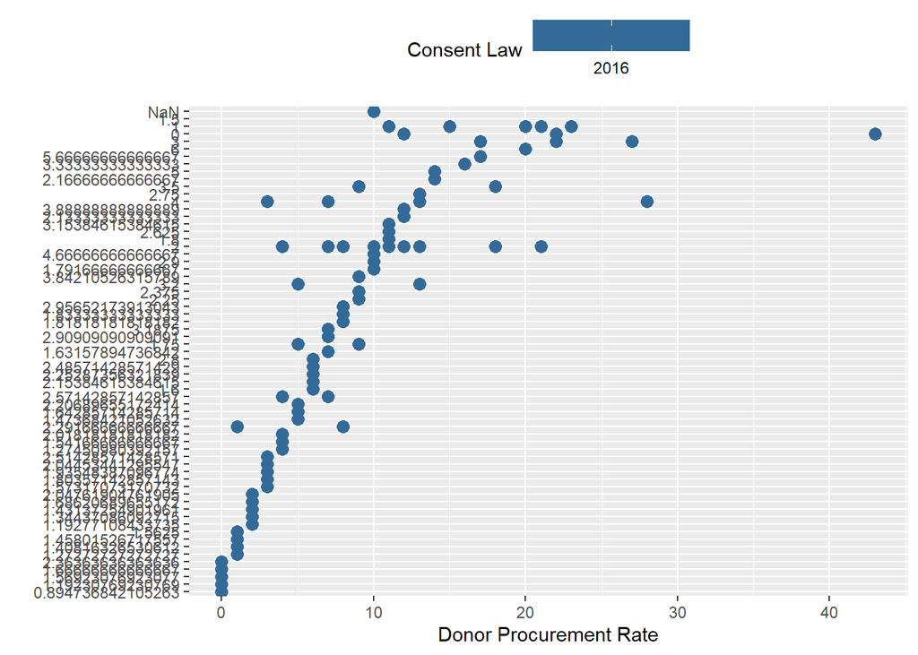

```r
p <- ggplot(data = by_degree, mapping = aes(x = sibs, y = reorder(childs_mean, sibs), color = year_mean))
p + geom_point(size=3) + labs(x = "Donor Procurement Rate", y = "", color = "Consent Law") + theme(legend.position="top")
```

```r
by_degree
```

| degree | sibs | year_mean | id_mean | ballot_mean | age_mean | childs_mean | pres12_mean | wtssall_mean | obama_mean | year_sd | id_sd | ballot_sd | age_sd | childs_sd | pres12_sd | wtssall_sd | obama_sd |
| --- | --- | --- | --- | --- | --- | --- | --- | --- | --- | --- | --- | --- | --- | --- | --- | --- | --- |
| Lt High School | 0 | 2016 | 1274.2727 | 2.090909 | 47.63636 | 2.3636364 | 1.200000 | 0.8817098 | 0.8000000 | 0 | 1006.592777 | 0.8312094 | 23.640105 | 2.5796406 | 0.4472136 | 0.4369517 | 0.4472136 |
| Lt High School | 1 | 2016 | 1507.2917 | 2.125000 | 40.75000 | 2.2916667 | 1.285714 | 0.9930400 | 0.7142857 | 0 | 823.494435 | 0.8501918 | 18.639019 | 2.2742255 | 0.4879500 | 0.5155247 | 0.4879500 |
| Lt High School | 2 | 2016 | 1626.4762 | 1.761905 | 49.04762 | 2.0476190 | 1.000000 | 1.3916808 | 1.0000000 | 0 | 804.005635 | 0.7684245 | 21.599713 | 1.6271506 | 0.0000000 | 0.7698436 | 0.0000000 |
| Lt High School | 3 | 2016 | 1571.0000 | 2.000000 | 48.91429 | 2.5142857 | 1.500000 | 1.0151054 | 0.5000000 | 0 | 754.804610 | 0.8401681 | 18.762245 | 1.9609636 | 0.5345225 | 0.5935561 | 0.5345225 |
| Lt High School | 4 | 2016 | 1420.8600 | 2.020000 | 50.02000 | 2.5714286 | 1.250000 | 0.9603109 | 0.7500000 | 0 | 820.450001 | 0.7951383 | 19.235904 | 1.6832508 | 0.4472136 | 0.4065072 | 0.4472136 |
| Lt High School | 5 | 2016 | 1889.8750 | 2.000000 | 59.69231 | 3.2000000 | 1.352941 | 1.0632832 | 0.6470588 | 0 | 840.031293 | 0.8770580 | 18.623915 | 2.0531402 | 0.4925922 | 0.6413244 | 0.4925922 |
| Lt High School | 6 | 2016 | 1429.1944 | 1.916667 | 56.77778 | 2.4857143 | 1.133333 | 1.0436542 | 0.8666667 | 0 | 829.664263 | 0.9063270 | 15.908867 | 1.5972666 | 0.3518658 | 0.5734196 | 0.3518658 |
| Lt High School | 7 | 2016 | 1364.0000 | 2.227273 | 48.31818 | 2.9090909 | 1.000000 | 1.1920656 | 1.0000000 | 0 | 916.057027 | 0.7516216 | 20.162167 | 2.4477218 | 0.0000000 | 0.7804617 | 0.0000000 |
| Lt High School | 8 | 2016 | 1446.0435 | 1.739130 | 52.08696 | 2.9565217 | 1.000000 | 0.9662025 | 1.0000000 | 0 | 929.425457 | 0.7518094 | 13.760659 | 1.9418422 | 0.0000000 | 0.4075344 | 0.0000000 |
| Lt High School | 9 | 2016 | 1670.4211 | 2.000000 | 56.78947 | 3.8421053 | 1.333333 | 0.8950070 | 0.6666667 | 0 | 782.840009 | 0.8164966 | 17.443811 | 2.1670040 | 0.5163978 | 0.2888491 | 0.5163978 |

[output cut: 83 more lines]

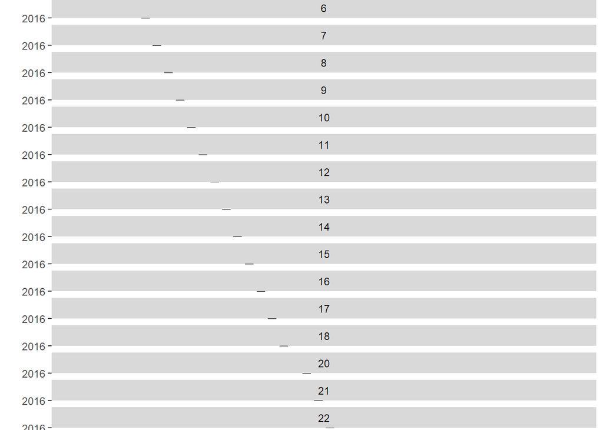

```r
p <- ggplot(data = by_degree, mapping = aes(x = sibs, y = reorder(year_mean, sibs)))
p + geom_point(size=3) + facet_wrap(~ sibs, scales = "free_y", ncol = 1) + labs(x= "Donor Procurement Rate", y = "")
```

```r
by_degree
```

| degree | sibs | year_mean | id_mean | ballot_mean | age_mean | childs_mean | pres12_mean | wtssall_mean | obama_mean | year_sd | id_sd | ballot_sd | age_sd | childs_sd | pres12_sd | wtssall_sd | obama_sd |
| --- | --- | --- | --- | --- | --- | --- | --- | --- | --- | --- | --- | --- | --- | --- | --- | --- | --- |
| Lt High School | 0 | 2016 | 1274.2727 | 2.090909 | 47.63636 | 2.3636364 | 1.200000 | 0.8817098 | 0.8000000 | 0 | 1006.592777 | 0.8312094 | 23.640105 | 2.5796406 | 0.4472136 | 0.4369517 | 0.4472136 |
| Lt High School | 1 | 2016 | 1507.2917 | 2.125000 | 40.75000 | 2.2916667 | 1.285714 | 0.9930400 | 0.7142857 | 0 | 823.494435 | 0.8501918 | 18.639019 | 2.2742255 | 0.4879500 | 0.5155247 | 0.4879500 |
| Lt High School | 2 | 2016 | 1626.4762 | 1.761905 | 49.04762 | 2.0476190 | 1.000000 | 1.3916808 | 1.0000000 | 0 | 804.005635 | 0.7684245 | 21.599713 | 1.6271506 | 0.0000000 | 0.7698436 | 0.0000000 |
| Lt High School | 3 | 2016 | 1571.0000 | 2.000000 | 48.91429 | 2.5142857 | 1.500000 | 1.0151054 | 0.5000000 | 0 | 754.804610 | 0.8401681 | 18.762245 | 1.9609636 | 0.5345225 | 0.5935561 | 0.5345225 |
| Lt High School | 4 | 2016 | 1420.8600 | 2.020000 | 50.02000 | 2.5714286 | 1.250000 | 0.9603109 | 0.7500000 | 0 | 820.450001 | 0.7951383 | 19.235904 | 1.6832508 | 0.4472136 | 0.4065072 | 0.4472136 |
| Lt High School | 5 | 2016 | 1889.8750 | 2.000000 | 59.69231 | 3.2000000 | 1.352941 | 1.0632832 | 0.6470588 | 0 | 840.031293 | 0.8770580 | 18.623915 | 2.0531402 | 0.4925922 | 0.6413244 | 0.4925922 |
| Lt High School | 6 | 2016 | 1429.1944 | 1.916667 | 56.77778 | 2.4857143 | 1.133333 | 1.0436542 | 0.8666667 | 0 | 829.664263 | 0.9063270 | 15.908867 | 1.5972666 | 0.3518658 | 0.5734196 | 0.3518658 |
| Lt High School | 7 | 2016 | 1364.0000 | 2.227273 | 48.31818 | 2.9090909 | 1.000000 | 1.1920656 | 1.0000000 | 0 | 916.057027 | 0.7516216 | 20.162167 | 2.4477218 | 0.0000000 | 0.7804617 | 0.0000000 |
| Lt High School | 8 | 2016 | 1446.0435 | 1.739130 | 52.08696 | 2.9565217 | 1.000000 | 0.9662025 | 1.0000000 | 0 | 929.425457 | 0.7518094 | 13.760659 | 1.9418422 | 0.0000000 | 0.4075344 | 0.0000000 |
| Lt High School | 9 | 2016 | 1670.4211 | 2.000000 | 56.78947 | 3.8421053 | 1.333333 | 0.8950070 | 0.6666667 | 0 | 782.840009 | 0.8164966 | 17.443811 | 2.1670040 | 0.5163978 | 0.2888491 | 0.5163978 |

[output cut: 83 more lines]

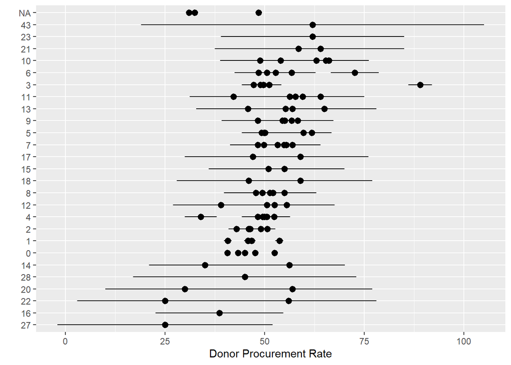

```r
p <- ggplot(data = by_degree, mapping = aes(x = reorder(sibs, age_mean), y = age_mean))
p + geom_pointrange(mapping = aes(ymin = age_mean - sibs, ymax = age_mean + sibs)) + labs(x= "", y= "Donor Procurement Rate") + coord_flip()
```

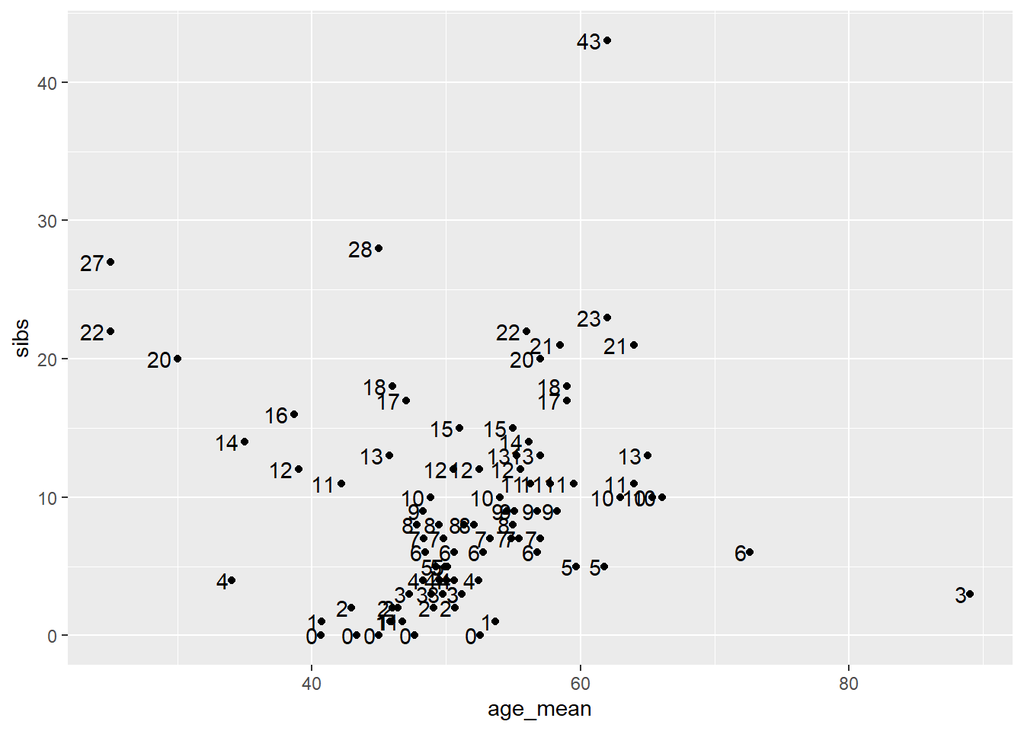

```r
p <- ggplot(data = by_degree, mapping = aes(x = age_mean, y = sibs))
p + geom_point() + geom_text(mapping = aes(label = sibs), hjust = 1.25)
```

A seguir, o livro usa o dataset “election_historic”. Eu usei o dataset election.

```r
library(ggrepel)
election
```

| state | st | fips | total_vote | vote_margin | winner | party | pct_margin | r_points | d_points | pct_clinton | pct_trump | pct_johnson | pct_other | clinton_vote | trump_vote | johnson_vote | other_vote | ev_dem | ev_rep | ev_oth | census |
| --- | --- | --- | --- | --- | --- | --- | --- | --- | --- | --- | --- | --- | --- | --- | --- | --- | --- | --- | --- | --- | --- |
| Alabama | AL | 1 | 2123372 | 588708 | Trump | Republican | 0.2773 | 27.72 | -27.72 | 34.36 | 62.08 | 2.09 | 1.46 | 729547 | 1318255 | 44467 | 31103 | 0 | 9 | 0 | South |
| Alaska | AK | 2 | 318608 | 46933 | Trump | Republican | 0.1473 | 14.73 | -14.73 | 36.55 | 51.28 | 5.88 | 6.29 | 116454 | 163387 | 18725 | 20042 | 0 | 3 | 0 | West |
| Arizona | AZ | 4 | 2604657 | 91234 | Trump | Republican | 0.0350 | 3.50 | -3.50 | 44.58 | 48.08 | 4.08 | 3.25 | 1161167 | 1252401 | 106327 | 84762 | 0 | 11 | 0 | West |
| Arkansas | AR | 5 | 1130635 | 304378 | Trump | Republican | 0.2692 | 26.92 | -26.92 | 33.65 | 60.57 | 2.64 | 3.13 | 380494 | 684872 | 29829 | 35440 | 0 | 6 | 0 | South |
| California | CA | 6 | 14237893 | 4269978 | Clinton | Democratic | 0.2999 | -29.99 | 29.99 | 61.48 | 31.49 | 3.36 | 3.66 | 8753792 | 4483814 | 478500 | 521787 | 55 | 0 | 0 | West |
| Colorado | CO | 8 | 2780247 | 136386 | Clinton | Democratic | 0.0491 | -4.91 | 4.91 | 48.16 | 43.25 | 5.18 | 3.41 | 1338870 | 1202484 | 144121 | 94772 | 9 | 0 | 0 | West |
| Connecticut | CT | 9 | 1644920 | 224357 | Clinton | Democratic | 0.1364 | -13.64 | 13.64 | 54.57 | 40.93 | 2.96 | 1.55 | 897572 | 673215 | 48676 | 25457 | 7 | 0 | 0 | Northeast |
| Delaware | DE | 10 | 443814 | 50476 | Clinton | Democratic | 0.1137 | -11.38 | 11.38 | 53.09 | 41.71 | 3.33 | 1.88 | 235603 | 185127 | 14757 | 8327 | 3 | 0 | 0 | South |
| District of Columbia | DC | 11 | 311268 | 270107 | Clinton | Democratic | 0.8678 | -86.77 | 86.77 | 90.86 | 4.09 | 1.58 | 3.47 | 282830 | 12723 | 4906 | 10809 | 3 | 0 | 0 | South |
| Florida | FL | 12 | 9502747 | 112911 | Trump | Republican | 0.0119 | 1.19 | -1.19 | 47.41 | 48.60 | 2.18 | 1.82 | 4504975 | 4617886 | 207043 | 172843 | 0 | 29 | 0 | South |

[output cut: 41 more lines]

```r
election %>% select (2:7)
```

| st | fips | total_vote | vote_margin | winner | party |
| --- | --- | --- | --- | --- | --- |
| AL | 1 | 2123372 | 588708 | Trump | Republican |
| AK | 2 | 318608 | 46933 | Trump | Republican |
| AZ | 4 | 2604657 | 91234 | Trump | Republican |
| AR | 5 | 1130635 | 304378 | Trump | Republican |
| CA | 6 | 14237893 | 4269978 | Clinton | Democratic |
| CO | 8 | 2780247 | 136386 | Clinton | Democratic |
| CT | 9 | 1644920 | 224357 | Clinton | Democratic |
| DE | 10 | 443814 | 50476 | Clinton | Democratic |
| DC | 11 | 311268 | 270107 | Clinton | Democratic |
| FL | 12 | 9502747 | 112911 | Trump | Republican |

[output cut: 41 more lines]

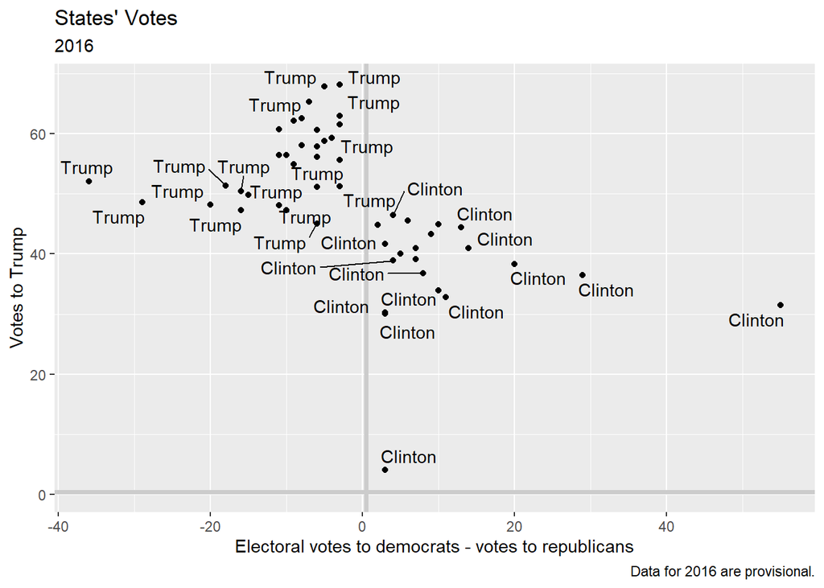

```r
p_title <- "States' Votes"
p_subtitle <- "2016"
p_caption <- "Data for 2016 are provisional."

x_label <- "Electoral votes to democrats - votes to republicans"
y_label <- "Votes to Trump"
p <- ggplot(election, aes(x = ev_dem - ev_rep, y = pct_trump, label = winner))
p + geom_hline(yintercept = 0.5, size = 1.4, color = "gray80") +
  geom_vline(xintercept = 0.5, size = 1.4, color = "gray80") +
  geom_point() +
  geom_text_repel() +
  labs(x = x_label, y = y_label, title = p_title, subtitle = p_subtitle, caption = p_caption)
```

```r
pilili <- ggplot(data = organdata, mapping = aes(x = roads, y = donors,
color = world))
pilili <- pilili + geom_point() + labs(x = "Road Deaths", y = "Donor Procurement") +
guides(color = FALSE)
gss_sm %>% group_by(race, degree) %>% summarize(N = n()) %>%
mutate(pct = round(N/sum(N) * 180, 0))
```

| race | degree | N | pct |
| --- | --- | --- | --- |
| White | Lt High School | 197 | 17 |
| White | High School | 1057 | 91 |
| White | Junior College | 166 | 14 |
| White | Bachelor | 426 | 37 |
| White | Graduate | 250 | 21 |
| White | NA | 4 | 0 |
| Black | Lt High School | 60 | 22 |
| Black | High School | 292 | 107 |
| Black | Junior College | 33 | 12 |
| Black | Bachelor | 71 | 26 |

[output cut: 8 more lines]

# Exercício 3

O gráfico escolhido para refinamento foi distribuição de patient outcome por tratamento.

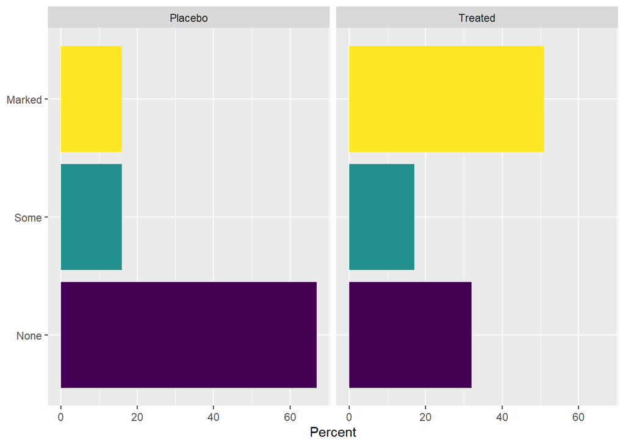

```r
library(dichromat)
library(RColorBrewer)
pupipe
```

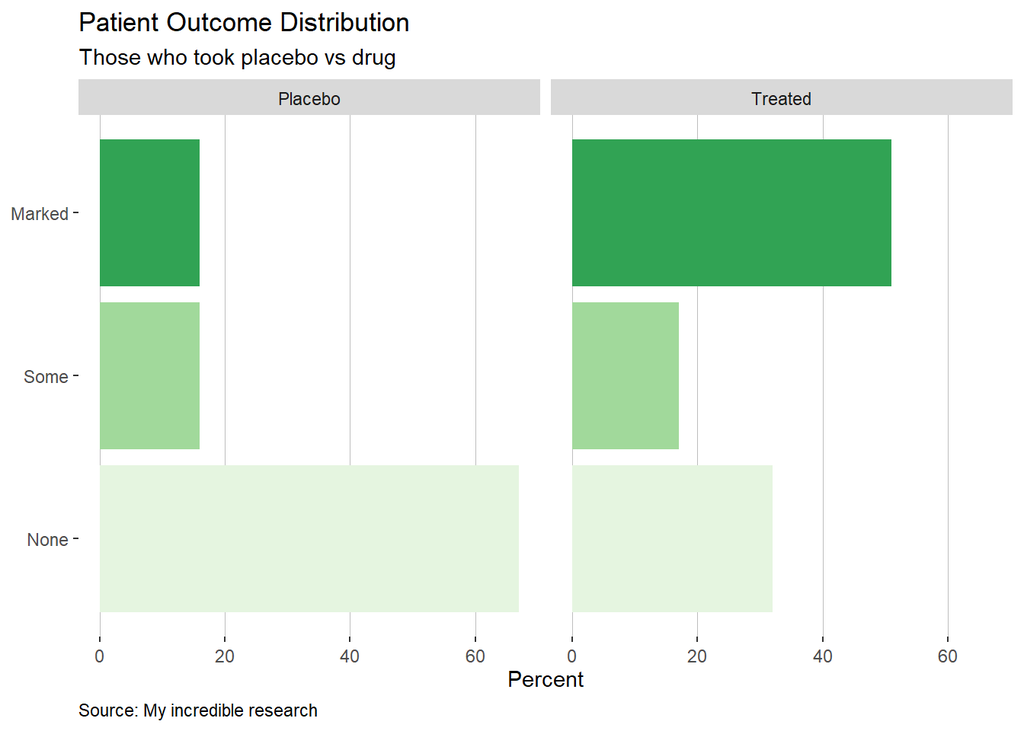

```r
g <- pupipe

g <- g + scale_fill_brewer(palette = "Deuteronopia") +
          theme(panel.background = element_rect(fill = 'white'),
                  plot.caption = element_text(hjust = 0),
                  axis.text.x = element_text(vjust = 0.5),
                  panel.grid.major.x = element_line(colour = "grey", size = 0.05)) +
          labs(title = "Patient Outcome Distribution",
               subtitle = 'Those who took placebo vs drug',
               caption = 'Source: My incredible research')
g
```

# Exercício 4

O gráfico escolhido está disponível em https://g1.globo.com/economia/noticia/2022/05/31/inflacao-e-protagonista-em-aumento-de-incerteza-com-economia-brasileira-diz-fgv-ibre.ghtml (acesso em 31/05/2022).

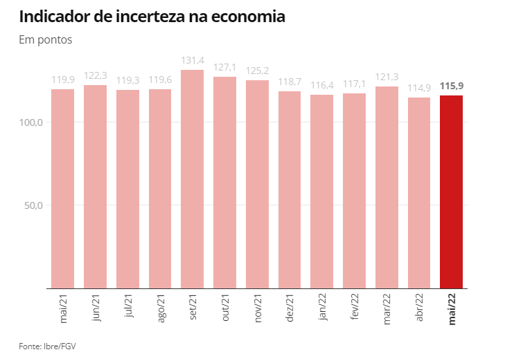

Um gráfico muito louco!

```r
library('tidyverse')

meses <- c('mai/21', 'jun/21', 'jul/21', 'ago/21', 'set/21', 'out/21', 'nov/21', 'dez/21', 'jan/22', 'fev/22', 'mar/22', 'abr/22', 'mai/22')

incerteza <- c(119.9, 122.3, 119.3, 119.6, 131.4, 127.1, 125.2, 118.7, 116.4, 117.1, 121.3, 114.9, 115.9)

indice <- c(1, 2, 3, 4, 5, 6, 7, 8, 9, 10, 11, 12, 13)

df <- data.frame(meses, incerteza, indice)
dadinhos <- as_tibble(df)

dadinhos
```

| meses | incerteza | indice |
| --- | --- | --- |
| mai/21 | 119.9 | 1 |
| jun/21 | 122.3 | 2 |
| jul/21 | 119.3 | 3 |
| ago/21 | 119.6 | 4 |
| set/21 | 131.4 | 5 |
| out/21 | 127.1 | 6 |
| nov/21 | 125.2 | 7 |
| dez/21 | 118.7 | 8 |
| jan/22 | 116.4 | 9 |
| fev/22 | 117.1 | 10 |

[output cut: 3 more lines]

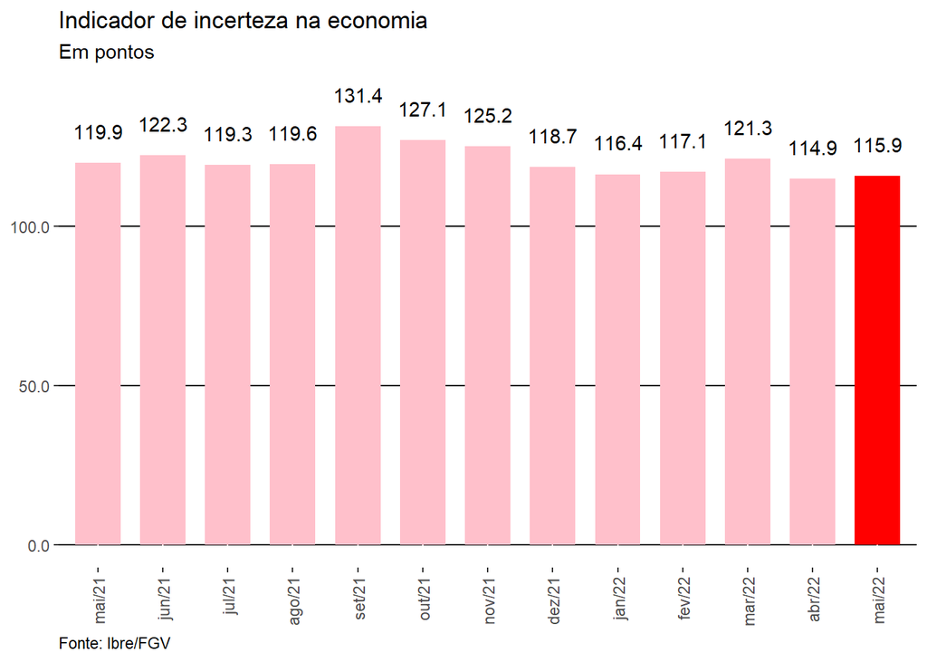

```r
grafinho <- ggplot(dadinhos, aes(x = reorder(meses, indice),
                                 y = incerteza)) +
            geom_bar(stat = 'identity',
                     width = 0.70,
                     fill = 'pink') +
            labs(x = NULL,
                 y = NULL,
                 title = 'Indicador de incerteza na economia',
                 subtitle = 'Em pontos',
                 caption = 'Fonte: Ibre/FGV') +
            geom_text(label = dadinhos$incerteza, nudge_y = 10) +
            theme(panel.background = element_rect(fill = 'white'),
                  plot.caption = element_text(hjust = 0),
                  axis.text.x = element_text(angle = 90, vjust = 0.5, hjust=1),
                  panel.grid.major.y = element_line(colour = "black", size = 0.5)) +
            scale_y_continuous(labels = scales::number_format(accuracy = 0.1)) +
            geom_bar(data = filter(dadinhos, indice == 13),
                     stat = 'identity',
                     width = 0.70,
                     fill = 'red')

grafinho
```

```r
ggsave("grafinho.png", grafinho)
```

O ajuste de cada elemento não é difícil, mas requer pesquisar a sintaxe específica (embora seja possível “chutar” e acertar às vezes).

Como este gráfico foi produzido antes de entrar em contato com a biblioteca Lubridate, criei uma coluna índice para poder ordenar os dados, já que o padrão é ordem alfabética.

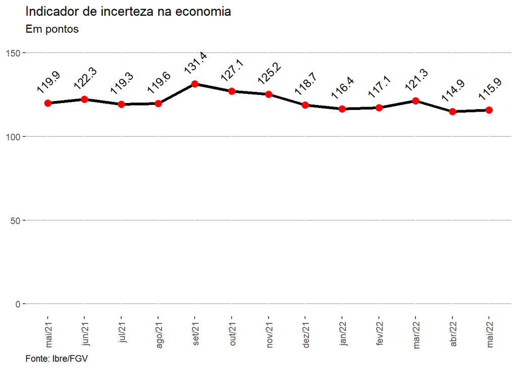

```r
grafinho <- ggplot(dadinhos, aes(x = reorder(meses, indice),
                                 y = incerteza)) +
            geom_line(data = dadinhos, mapping = aes(x = reorder(meses, indice),
                                                     y = incerteza,
                                                     group = 1),
                      color = 'black',
                      size = 1.25) +
            geom_point(data = dadinhos, mapping = aes(x = reorder(meses, indice),
                                                     y = incerteza,
                                                     group = 1),
                      color = 'red',
                      size = 3) +
            geom_text(label = dadinhos$incerteza, nudge_y = 12.5, angle = 45) +
            labs(x = NULL,
                 y = NULL,
                 title = 'Indicador de incerteza na economia',
                 subtitle = 'Em pontos',
                 caption = 'Fonte: Ibre/FGV') +
            theme(panel.background = element_rect(fill = 'white'),
                  plot.caption = element_text(hjust = 0),
                  axis.text.x = element_text(angle = 90, vjust = 0.5, hjust=1),
                  panel.grid.major.y = element_line(colour = "grey", size = 0.5)) +
                  scale_y_continuous(limits = c(0, 150))

grafinho
```

Já ficou mais elegante, mas eu tive uma ideia interessante: (supondo que incerteza seja ruim) colorir de vermelho os segmentos em que houve piora e de verde os em que houve melhora.

```r
dadinhos
```

| meses | incerteza | indice |
| --- | --- | --- |
| mai/21 | 119.9 | 1 |
| jun/21 | 122.3 | 2 |
| jul/21 | 119.3 | 3 |
| ago/21 | 119.6 | 4 |
| set/21 | 131.4 | 5 |
| out/21 | 127.1 | 6 |
| nov/21 | 125.2 | 7 |
| dez/21 | 118.7 | 8 |
| jan/22 | 116.4 | 9 |
| fev/22 | 117.1 | 10 |

[output cut: 3 more lines]

```r
conjuntinho <- c()
conjuntinho
```

```r
for (i in seq(from = 1, to = 12, by = 1)) {
  if (dadinhos[[i, 2]] > dadinhos[[i+1, 2]]) {
    conjuntinho <- c(conjuntinho, 'green')
  } else {conjuntinho <- c(conjuntinho, 'red')}
}

conjuntinho <- c(conjuntinho, 0)

meses <- c('a: mai/21', 'b: jun/21', 'c: jul/21', 'd: ago/21', 'e: set/21', 'f: out/21', 'g: nov/21', 'h: dez/21', 'i: jan/22', 'j: fev/22', 'k: mar/22', 'l: abr/22', 'm: mai/22')

dadinhos <- as_tibble(data.frame(meses, incerteza, indice,conjuntinho))
dadinhos
```

| meses | incerteza | indice | conjuntinho |
| --- | --- | --- | --- |
| a: mai/21 | 119.9 | 1 | red |
| b: jun/21 | 122.3 | 2 | green |
| c: jul/21 | 119.3 | 3 | red |
| d: ago/21 | 119.6 | 4 | red |
| e: set/21 | 131.4 | 5 | green |
| f: out/21 | 127.1 | 6 | green |
| g: nov/21 | 125.2 | 7 | green |
| h: dez/21 | 118.7 | 8 | green |
| i: jan/22 | 116.4 | 9 | red |
| j: fev/22 | 117.1 | 10 | red |

[output cut: 3 more lines]

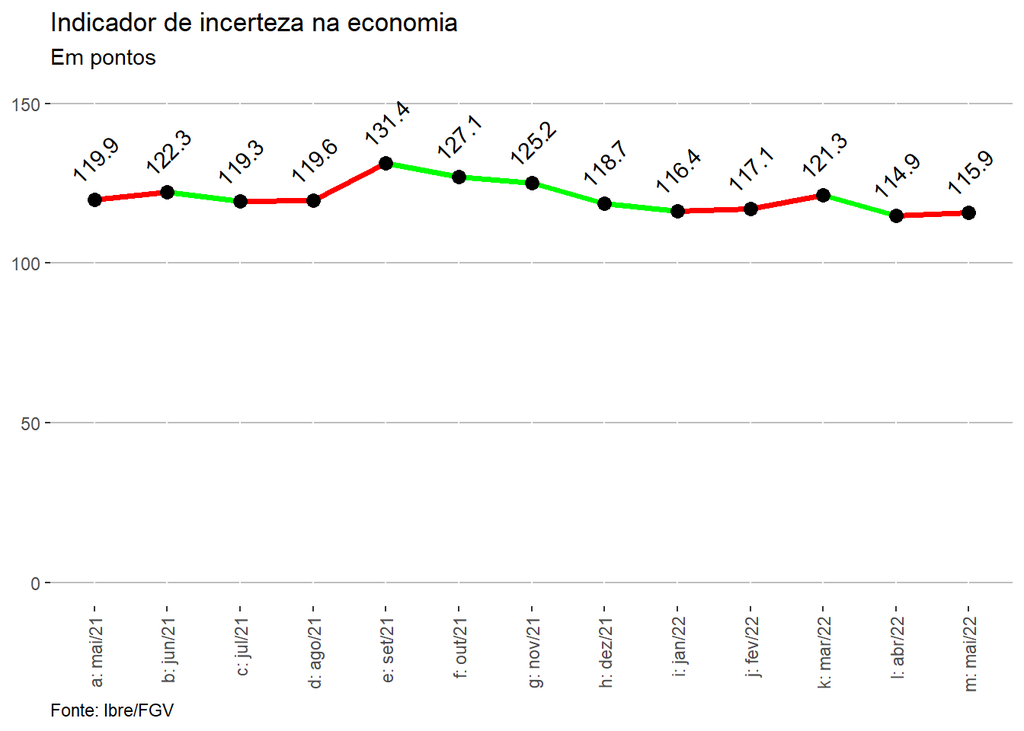

```r
asla_fan_club <- ggplot(dadinhos, aes(x = reorder(meses, indice),
                                 y = incerteza)) +
  # É uma pena não poder usar for loops dentro do ggplot
            geom_segment(data = dadinhos, mapping = aes(x = meses[1],
                                                        xend = meses[2],
                                                        y = incerteza[1],
                                                        yend = incerteza[2],
                                                        group = 1),
                      color = conjuntinho[1],
                      size = 1.25) +
            geom_segment(data = dadinhos, mapping = aes(x = meses[2],
                                                        xend = meses[3],
                                                        y = incerteza[2],
                                                        yend = incerteza[3],
                                                        group = 1),
                      color = conjuntinho[2],
                      size = 1.25) +
            geom_segment(data = dadinhos, mapping = aes(x = meses[3],
                                                        xend = meses[4],
                                                        y = incerteza[3],
                                                        yend = incerteza[4],
                                                        group = 1),
                      color = conjuntinho[3],
                      size = 1.25) +
            geom_segment(data = dadinhos, mapping = aes(x = meses[4],
                                                        xend = meses[5],
                                                        y = incerteza[4],
                                                        yend = incerteza[5],
                                                        group = 1),
                      color = conjuntinho[4],
                      size = 1.25) +
            geom_segment(data = dadinhos, mapping = aes(x = meses[5],
                                                        xend = meses[6],
                                                        y = incerteza[5],
                                                        yend = incerteza[6],
                                                        group = 1),
                      color = conjuntinho[5],
                      size = 1.25) +
            geom_segment(data = dadinhos, mapping = aes(x = meses[6],
                                                        xend = meses[7],
                                                        y = incerteza[6],
                                                        yend = incerteza[7],
                                                        group = 1),
                      color = conjuntinho[6],
                      size = 1.25) +
            geom_segment(data = dadinhos, mapping = aes(x = meses[7],
                                                        xend = meses[8],
                                                        y = incerteza[7],
                                                        yend = incerteza[8],
                                                        group = 1),
                      color = conjuntinho[7],
                      size = 1.25) +
            geom_segment(data = dadinhos, mapping = aes(x = meses[8],
                                                        xend = meses[9],
                                                        y = incerteza[8],
                                                        yend = incerteza[9],
                                                        group = 1),
                      color = conjuntinho[8],
                      size = 1.25) +
            geom_segment(data = dadinhos, mapping = aes(x = meses[9],
                                                        xend = meses[10],
                                                        y = incerteza[9],
                                                        yend = incerteza[10],
                                                        group = 1),
                      color = conjuntinho[9],
                      size = 1.25) +
            geom_segment(data = dadinhos, mapping = aes(x = meses[10],
                                                        xend = meses[11],
                                                        y = incerteza[10],
                                                        yend = incerteza[11],
                                                        group = 1),
                      color = conjuntinho[10],
                      size = 1.25) +
            geom_segment(data = dadinhos, mapping = aes(x = meses[11],
                                                        xend = meses[12],
                                                        y = incerteza[11],
                                                        yend = incerteza[12],
                                                        group = 1),
                      color = conjuntinho[11],
                      size = 1.25) +
            geom_segment(data = dadinhos, mapping = aes(x = meses[12],
                                                        xend = meses[13],
                                                        y = incerteza[12],
                                                        yend = incerteza[13],
                                                        group = 1),
                      color = conjuntinho[12],
                      size = 1.25) +
            geom_point(data = dadinhos, mapping = aes(x = reorder(meses, indice),
                                                     y = incerteza,
                                                     group = 1),
                      color = 'black',
                      size = 3) +
            geom_text(label = dadinhos$incerteza, nudge_y = 12.5, angle = 45) +
            labs(x = NULL,
                 y = NULL,
                 title = 'Indicador de incerteza na economia',
                 subtitle = 'Em pontos',
                 caption = 'Fonte: Ibre/FGV') +
            theme(panel.background = element_rect(fill = 'white'),
                  plot.caption = element_text(hjust = 0),
                  axis.text.x = element_text(angle = 90, vjust = 0.5, hjust=1),
                  panel.grid.major.y = element_line(colour = "grey", size = 0.5)) +
                  scale_y_continuous(limits = c(0, 150))
asla_fan_club
```

Se isso não for o bastante para ignorar a baixa qualidade da feitura dos outros exercícios, eu não sei o que sê-lo-ia.